# Homework3

## Problem 2: Automatic Document Clustering

### For this problem you will use a different subset of the 20 Newsgroup data set that you used in Assignment 2 (see the description of the full dataset). The subset for this assignment includes 2,500 documents (newsgroup posts), each belonging to one of 5 categories windows (0), crypt (1), christian (2), hockey (3), forsale (4). The documents are represented by 9328 terms (stems). The dictionary (vocabulary) for the data set is given in the file "terms.txt" and the full term-by-document matrix is given in "matrix.txt" (comma separated values). The actual category labels for the documents are provided in the file "classes.txt". Your goal in this assignment is to perform clustering on the documents and compare the clusters to the actual categories.

### Your tasks in this problem are the following [Note: for the clustering part of this assignment you should use the kMeans module form Ch. 10 of MLA (use the version provided here as it includes some corrections to the book version). You may also use Pandas and other modules from scikit-learn that you may need for preprocessing or evaluation.]

### a. Create your own distance function that, instead of using Euclidean distance, uses Cosine similarity. This is the distance function you will use to pass to the kMeans function.

```python
def CosSim(vecA, vecB):
    # first find the vector norm for each instance in D as wel as the norm for vector x
    normA = linalg.norm(vecA)
    normB = linalg.norm(vecB)
    # Compute Cosine: divide the dot product o x and each instance in D by the product of the two norms
    sims = dot(vecA, vecB)/(normA * normB)
    # The distance measure will be the inverse of Cosine similarity
    dists = 1 - sims
    return dists
```

### b. Load the data set [Note: the data matrix provided has terms as rows and documents as columns. Since you will be clustering documents, you'll need to take the transpose of this matrix so that your main data matrix is a document x term matrix. In Numpy, you may use the ".T" operation to obtain the transpose.] Then, split the data set (the document x term matrix) and set aside 20% for later use (see below). Use the 80% segment for clustering in the next part. The 20% portion must be a random subset.

##### Load the data set [Note: the data matrix provided has terms as rows and documents as columns. Since you will be clustering documents, you'll need to take the transpose of this matrix so that your main data matrix is a document x term matrix. In Numpy, you may use the ".T" operation to obtain the transpose.]

```python
import numpy as np
from numpy import *

data = pd.DataFrame(np.genfromtxt(path + '/newsgroups5/matrix.txt', delimiter = ',', dtype = int)).T
data.head(5)
```

|  | 0 | 1 | 2 | 3 | 4 | 5 | 6 | 7 | 8 | 9 | ... | 9318 | 9319 | 9320 | 9321 | 9322 | 9323 | 9324 | 9325 | 9326 | 9327 |
| --- | --- | --- | --- | --- | --- | --- | --- | --- | --- | --- | --- | --- | --- | --- | --- | --- | --- | --- | --- | --- | --- |
| 0 | 0 | 0 | 0 | 0 | 0 | 0 | 0 | 0 | 0 | 0 | ... | 0 | 0 | 0 | 0 | 0 | 0 | 0 | 0 | 0 | 0 |
| 1 | 0 | 0 | 0 | 0 | 0 | 0 | 0 | 0 | 0 | 1 | ... | 0 | 0 | 0 | 0 | 0 | 0 | 0 | 0 | 0 | 0 |
| 2 | 0 | 0 | 0 | 0 | 0 | 0 | 0 | 0 | 0 | 0 | ... | 0 | 0 | 0 | 0 | 0 | 0 | 0 | 0 | 0 | 0 |
| 3 | 0 | 0 | 0 | 0 | 0 | 0 | 0 | 0 | 0 | 0 | ... | 0 | 0 | 0 | 0 | 0 | 0 | 0 | 0 | 0 | 0 |
| 4 | 0 | 0 | 0 | 0 | 0 | 0 | 0 | 0 | 0 | 0 | ... | 0 | 0 | 0 | 0 | 0 | 0 | 0 | 0 | 0 | 0 |

5 rows × 9328 columns

```python
y = np.genfromtxt(path + '/newsgroups5/classes.txt', delimiter=' ', dtype=int, skip_header=1, usecols=(1))
y.shape
```

```
(2500,)
```

```python
label = pd.read_table(path + '/newsgroups5/terms.txt', sep='\n', header=None)
label.shape
```

```
(9328, 1)
```

```python
label.head()
```

|  | 0 |
| --- | --- |
| 0 | aa |
| 1 | aargh |
| 2 | aaron |
| 3 | aaronc |
| 4 | ab |

##### Then, split the data set (the document x term matrix) and set aside 20% for later use (see below). Use the 80% segment for clustering in the next part. The 20% portion must be a random subset.

```python
from sklearn.model_selection import train_test_split

x_train, x_test, y_train, y_test = train_test_split(data, y, test_size=0.2, random_state=33)
x_train.shape
```

```
(2000, 9328)
```

```python
x_test.shape
```

```
(500, 9328)
```

### c. Perform Kmeans clustering on the training data. Write a function to display the top N terms in each cluster along with the cluster DF values for each term and the size of the cluster. The cluster DF value for a term t in a cluster C is the percentage of docs in cluster C in which term t appears (so, if a cluster has 500 documents, and term "game" appears in 100 of those 500 documents, then DF value of "game" in that cluster is 0.2 or 20%). Sort the terms for each cluster in decreasing order of the DF percentage. Here is an example of how this output might look like (here the top 10 terms for some clusters and the data are displayed in decreasing order of cluster DF values). [Extra Credit: use your favorite third party tool, ideally with a Python based API, to create a word cloud for each cluster.]

```python
def distEuclid(vecA, vecB):
    return sqrt(sum(power(vecA - vecB, 2))) #la.norm(vecA-vecB)
```

```python
def randCent(dataSet, k):
    'returns random centroids'
    n = shape(dataSet)[1]
    centroids = zeros((k,n), dtype=float)
    for j in range(n):
        minJ = min(dataSet[:,j])
        rangeJ = float(max(dataSet[:,j]) - minJ)
        centroids[:,j] = minJ + rangeJ * random.rand(k)
    return centroids
```

```python
# kMeans function
from sklearn.cluster import KMeans

def kMeans(dataSet, k, distMeas=distEuclid, createCent=randCent):
    m = shape(dataSet)[0]
    clusterAssment = zeros((m,2))#create mat to assign data points
                                      #to a centroid, also holds SE of each point
    centroids = createCent(dataSet, k)
    clusterChanged = True
    while clusterChanged:
        clusterChanged = False
        for i in range(m):#for each data point assign it to the closest centroid
            minDist = inf; minIndex = -1
            for j in range(k):
                distJI = distMeas(centroids[j,:],dataSet[i,:])
                if distJI < minDist:
                    minDist = distJI; minIndex = j
            if clusterAssment[i,0] != minIndex: clusterChanged = True
            clusterAssment[i,:] = minIndex,minDist**2
        # print centroids
        for cent in range(k):#recalculate centroids
            ptsInClust = dataSet[nonzero(clusterAssment[:,0]==cent)[0]] #get all the point in this cluster - Note: this was incorrect in the original distribution.
            if(len(ptsInClust)!=0):
                centroids[cent,:] = mean(ptsInClust, axis=0) #assign centroid to mean - Note condition was added 10/28/2013
    return centroids, clusterAssment
```

```python
x_train_np = x_train.to_numpy()
centroids, clusterAssment = kMeans((x_train_np), 5, CosSim, randCent)
```

##### Write a function to display the top N terms in each cluster along with the cluster DF values for each term and the size of the cluster. The cluster DF value for a term t in a cluster C is the percentage of docs in cluster C in which term t appears (so, if a cluster has 500 documents, and term "game" appears in 100 of those 500 documents, then DF value of "game" in that cluster is 0.2 or 20%). Sort the terms for each cluster in decreasing order of the DF percentage. Here is an example of how this output might look like (here the top 10 terms for some clusters and the data are displayed in decreasing order of cluster DF values).

```python
def topTerms(N, centroids, clusterAssment):
    labels_list = pd.Series(label[0], name = 'term')
    clusters = pd.DataFrame(clusterAssment)

    for i in range(5):
        # Get indexes of items in this cluster
        print("Cluster %d results:" %(i+1))
        cluster_index = np.array(clusters.index[clusters.iloc[:,0] == i])
        centroid = pd.Series(centroids[i], name='value')
        cluster = pd.concat([labels_list, centroid], axis=1)
        cluster_df = cluster.iloc[cluster_index]

        cluster_len = len(cluster_index)
        cluster_df.sort_values(by='value', axis=0, ascending=False, inplace=True)

        tops = cluster_df.head(N)
        print('Numbers in this cluster: ', str(len(clusters)))
        print("\tword\t\tDF\tPercentofDocs")

        for j in tops.itertuples():
            DF = j.value * cluster_len
            percentD = j.value * 100
            print("%10s\t\t%.0f\t%.6f" %(j.term, DF, percentD))
        print ("-----------------------------------------------------")
```

```python
from pandas.core.common import SettingWithCopyWarning
warnings.simplefilter(action="ignore", category=SettingWithCopyWarning)
```

```python
topTerms(10, centroids, clusterAssment)
```

```
Cluster 1 results:
Numbers in this cluster:  2000
	word		DF	PercentofDocs
       cup		136	36.363636
        bh		128	34.224599
        al		94	25.133690
     bruin		90	24.064171
    boston		89	23.796791
     coach		76	20.320856
       dai		46	12.299465
   contact		45	12.032086
      beat		39	10.427807
     david		37	9.893048
-----------------------------------------------------
Cluster 2 results:
Numbers in this cluster:  2000
	word		DF	PercentofDocs
    applic		121	33.611111
    comput		90	25.000000
    access		64	17.777778
   comment		63	17.500000
     check		44	12.222222
    advanc		42	11.666667
   charact		42	11.666667
   appreci		36	10.000000
    anonym		36	10.000000
  configur		28	7.777778
-----------------------------------------------------
Cluster 3 results:
Numbers in this cluster:  2000
	word		DF	PercentofDocs
    ashton		0	0.000000
   atlanta		0	0.000000
        bo		0	0.000000
    broken		0	0.000000
cypherpunk		0	0.000000
 dcsedacuk		0	0.000000
-----------------------------------------------------
Cluster 4 results:
Numbers in this cluster:  2000
```

[output cut: 11 more lines]

```
-----------------------------------------------------
Cluster 5 results:
Numbers in this cluster:  2000
	word		DF	PercentofDocs
    condit		99	21.063830
      book		75	15.957447
      call		70	14.893617
      best		66	14.042553
       box		57	12.127660
   address		57	12.127660
      case		49	10.425532
    annual		42	8.936170
    articl		37	7.872340
       bui		34	7.234043
-----------------------------------------------------
```

##### [Extra Credit: use your favorite third party tool, ideally with a Python based API, to create a word cloud for each cluster.]

```python
# !pip install wordcloud
```

```python
import matplotlib.pyplot as plt
from wordcloud import WordCloud, ImageColorGenerator
```

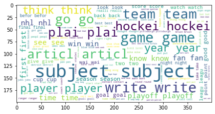

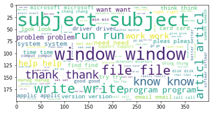

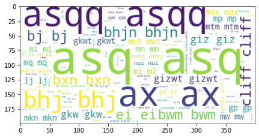

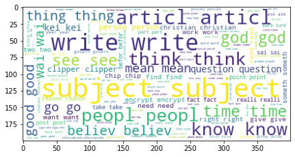

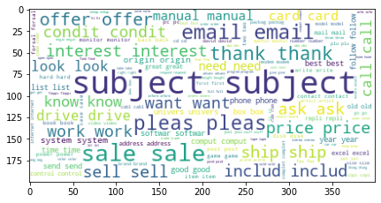

```python
t_list = list(np.array(label).T[0])
for i in range(5):
    c = pd.DataFrame(x_train[clusterAssment[:,0]==i])
    label_array = np.array(label)
    c.columns = label_array.T[0]
    c_freq = list(np.array((c.T!=0).sum(1).T))
    terms_list = list(label_array.T[0])
    c_words = ""

    index = 0
    for m in c_freq:
        for n in range(int(m)):
            c_words += t_list[index] + " "
        index += 1

    c_wordcloud = WordCloud(background_color='white').generate(c_words)
    plt.imshow(c_wordcloud)
    plt.show()
```

### d. Using the cluster assignments from Kmeans clustering, compare your 5 clusters to the 5 pre-assigned classes by computing the Completeness and Homogeneity values.

```python
from sklearn.metrics import completeness_score, homogeneity_score
```

```python
y_train
```

```
array([4, 0, 4, ..., 2, 0, 1])
```

```python
print("Completeness:",completeness_score(y_train,np.ravel(clusterAssment.T[0])))
print("Homogeneity:",homogeneity_score(y_train,np.ravel(clusterAssment.T[0])))
```

```
Completeness: 0.7101817003134634
Homogeneity: 0.5943810681449513
```

### e. Finally, using your cluster assignments as class labels, categorize each of the documents in the 20% set-aside data into each of the appropriate cluster. Your categorization should be based on Cosine similarity between each test document and cluster centroids. For each test document show the predicted class label as well as Cosine similarity to the corresponding cluster.

```python
res = []
x_test_np = x_test.to_numpy()

for doc in x_test_np:
    dic = {}
    sim = []
    cluster = 0
    for centroid in centroids:
        doc_sim = 1 - CosSim(doc, centroid) # subtract from 1 to get similarity
        sim.append(doc_sim)
        dic[cluster] = doc_sim
        cluster += 1
    dic['cluster prediction'] = sim.index(max(sim))
    res.append(dic)
```

```python
pd.set_option('display.max_rows', None)
pd.DataFrame(res)
```

|  | 0 | 1 | 2 | 3 | 4 | cluster prediction |
| --- | --- | --- | --- | --- | --- | --- |
| 0 | 0.102983 | 0.111768 | 0.000023 | 0.205000 | 0.127510 | 3 |
| 1 | 0.082183 | 0.100434 | 0.000007 | 0.214657 | 0.131763 | 3 |
| 2 | 0.097222 | 0.091258 | 0.000031 | 0.135844 | 0.214832 | 4 |
| 3 | 0.183512 | 0.429698 | 0.000027 | 0.276795 | 0.203913 | 1 |
| 4 | 0.145053 | 0.059696 | 0.000018 | 0.071345 | 0.288744 | 4 |
| 5 | 0.161050 | 0.182766 | 0.000022 | 0.412617 | 0.177088 | 3 |
| 6 | 0.414228 | 0.174549 | 0.000011 | 0.261914 | 0.176483 | 0 |
| 7 | 0.086066 | 0.121784 | 0.000022 | 0.186053 | 0.193230 | 4 |
| 8 | 0.152097 | 0.146955 | 0.000006 | 0.445308 | 0.157501 | 3 |
| 9 | 0.090502 | 0.100523 | 0.000010 | 0.158765 | 0.080878 | 3 |
| 10 | 0.068902 | 0.069373 | 0.000010 | 0.209054 | 0.081365 | 3 |
| 11 | 0.060775 | 0.099395 | 0.000023 | 0.082280 | 0.256030 | 4 |
| 12 | 0.129308 | 0.367415 | 0.000017 | 0.177184 | 0.167673 | 1 |
| 13 | 0.096540 | 0.118860 | 0.001436 | 0.116700 | 0.190413 | 4 |
| 14 | 0.057367 | 0.199950 | 0.000039 | 0.089697 | 0.185941 | 1 |
| 15 | 0.085389 | 0.250017 | 0.000022 | 0.135163 | 0.135950 | 1 |
| 16 | 0.197833 | 0.183397 | 0.000037 | 0.360461 | 0.182098 | 3 |
| 17 | 0.083205 | 0.109350 | 0.000012 | 0.258373 | 0.106248 | 3 |
| 18 | 0.100726 | 0.091068 | 0.000021 | 0.188426 | 0.128516 | 3 |
| 19 | 0.134601 | 0.446933 | 0.000012 | 0.204208 | 0.225367 | 1 |
| 20 | 0.077359 | 0.082587 | 0.000013 | 0.326789 | 0.114710 | 3 |
| 21 | 0.097868 | 0.102650 | 0.000020 | 0.262561 | 0.132377 | 3 |
| 22 | 0.078231 | 0.175722 | 0.000013 | 0.087757 | 0.214926 | 4 |
| 23 | 0.069252 | 0.204727 | 0.000026 | 0.103188 | 0.169126 | 1 |
| 24 | 0.091492 | 0.110919 | 0.000027 | 0.329105 | 0.109077 | 3 |
| 25 | 0.071444 | 0.179831 | 0.000016 | 0.128363 | 0.089361 | 1 |
| 26 | 0.268102 | 0.149065 | 0.000014 | 0.218081 | 0.174701 | 0 |
| 27 | 0.235873 | 0.088916 | 0.000038 | 0.123676 | 0.104823 | 0 |
| 28 | 0.052609 | 0.108124 | 0.000021 | 0.062787 | 0.289687 | 4 |
| 29 | 0.080036 | 0.109299 | 0.000015 | 0.249950 | 0.128262 | 3 |

[output cut: 470 more lines]